# Airbnb_marketing_data_analysis

## Airbnb Analysis

### Data load& merge

```python
# Import libraries
import pandas as pd
import numpy as np
import matplotlib.pyplot as plt
import seaborn as sns
from datetime import datetime
from sklearn.preprocessing import StandardScaler
import warnings
warnings.filterwarnings("ignore")
```

```python
# Import dataset: calendar, listing and reviews
pd.set_option('display.max_columns', None)
calendar = pd.read_csv('Airbnb_Albany_NY_dataset\calendar.csv')
listing = pd.read_csv('Airbnb_Albany_NY_dataset\listings.csv')
reviews = pd.read_csv(r'Airbnb_Albany_NY_dataset\reviews.csv')
```

- These dataset includes 3 data files: `Calendar.csv`, `Listing.csv`, `Reviews.csv`; the `listing_id`(Calendar.csv) = `id`(Listings.csv) = `listing_id` (Reviews.csv)

## Data Cleaning

##### `Calendar` cleaning

```python
# check calendar dataframe
calendar.head()
```

|  | listing_id | date | available | price | adjusted_price | minimum_nights | maximum_nights |
| --- | --- | --- | --- | --- | --- | --- | --- |
| 0 | 2992450.0 | 9/5/2024 | f | $132 | NaN | 28 | 1125 |
| 1 | 2992450.0 | 9/6/2024 | f | $133 | NaN | 28 | 1125 |
| 2 | 2992450.0 | 9/7/2024 | f | $129 | NaN | 28 | 1125 |
| 3 | 2992450.0 | 9/8/2024 | f | $135 | NaN | 28 | 1125 |
| 4 | 2992450.0 | 9/9/2024 | f | $124 | NaN | 28 | 1125 |

```python
# check the calendar columns
calendar.columns
```

```
Index(['listing_id', 'date', 'available', 'price', 'adjusted_price',
       'minimum_nights', 'maximum_nights'],
      dtype='object')
```

- Check null values

```python
# check the null values of calendar
print(f'The total number of calendar:{calendar.shape[0]}')
calendar.isnull().sum()
```

```
The total number of calendar:155490
```

```
listing_id             0
date                   0
available              0
price                  0
adjusted_price    155490
minimum_nights         0
maximum_nights         0
dtype: int64
```

```python
# Drop the 'adjusted_price' column because of no value
calendar= calendar.drop('adjusted_price',axis = 1)
```

- Check duplicate values

```python
# Check duplicates in calendar
print(f'The duplicates in calender:{calendar.duplicated().sum()}')
```

```
The duplicates in calender:110
```

```python
# Drop the duplicates
calendar = calendar.drop_duplicates()
```

```python
# check the data type of each column
calendar.info()
```

```
<class 'pandas.core.frame.DataFrame'>
Index: 155380 entries, 0 to 155489
Data columns (total 6 columns):
 #   Column          Non-Null Count   Dtype
---  ------          --------------   -----
 0   listing_id      155380 non-null  float64
 1   date            155380 non-null  object
 2   available       155380 non-null  object
 3   price           155380 non-null  object
 4   minimum_nights  155380 non-null  int64
 5   maximum_nights  155380 non-null  int64
dtypes: float64(1), int64(2), object(3)
memory usage: 8.3+ MB
```

- Convert data type

```python
# convert the 'price' into numeric column
calendar['price'] = (calendar['price']
                          .str.replace('$', '', regex=False)   # Remove dollar sign
                          .str.replace(',', '', regex=False)   # Remove commas
                          .astype('float32'))                   # Convert to float32
```

```python
# convet the value of available f into False, t into True
calendar['available'] = calendar['available'].replace({'f':False,'t':True})

# convert the date columns into datetype
calendar['date'] = pd.to_datetime(calendar['date'])

# add the month and weekday to 'date'
calendar['date_month'] = calendar['date'].dt.strftime('%Y-%m')
calendar['date_weekday'] =calendar['date'].dt.day_name()

# convert the numeric column of 'listing_id' into categorical column
calendar['listing_id'] = calendar['listing_id'].astype('object')
```

##### `Listing` cleaning

```python
# check listing first 5 rows
listing.head()
```

|  | id | name | host_id | host_name | neighbourhood_group | neighbourhood | latitude | longitude | room_type | price | minimum_nights | number_of_reviews | last_review | reviews_per_month | calculated_host_listings_count | availability_365 | number_of_reviews_ltm | license |
| --- | --- | --- | --- | --- | --- | --- | --- | --- | --- | --- | --- | --- | --- | --- | --- | --- | --- | --- |
| 0 | 2992450 | Luxury 2 bedroom apartment | 4621559 | Kenneth | NaN | THIRD WARD | 42.65789 | -73.75370 | Entire home/apt | 70.0 | 28 | 9 | 2022-08-17 | 0.07 | 1 | 158 | 0 | NaN |
| 1 | 3820211 | Restored Precinct in Center Sq. w/Parking | 19648678 | Terra | NaN | SIXTH WARD | 42.65222 | -73.76724 | Entire home/apt | 116.0 | 2 | 305 | 2024-07-31 | 2.49 | 4 | 336 | 16 | NaN |
| 2 | 5651579 | Large studio apt by Capital Center & ESP@ | 29288920 | Gregg | NaN | SECOND WARD | 42.64615 | -73.75966 | Entire home/apt | 75.0 | 2 | 366 | 2024-08-27 | 3.22 | 2 | 34 | 40 | NaN |
| 3 | 6623339 | Center Sq. Loft in Converted Precinct w/ Parking | 19648678 | Terra | NaN | SIXTH WARD | 42.65222 | -73.76724 | Entire home/apt | 116.0 | 2 | 328 | 2024-07-31 | 2.91 | 4 | 279 | 25 | NaN |
| 4 | 8035768 | Entire Beautiful French Victorian 1884 | 42430824 | John M | NaN | TENTH WARD | 42.66088 | -73.78147 | Entire home/apt | 305.0 | 2 | 56 | 2024-01-28 | 0.51 | 2 | 362 | 4 | NaN |

```python
# check columns
listing.columns
```

```
Index(['id', 'name', 'host_id', 'host_name', 'neighbourhood_group',
       'neighbourhood', 'latitude', 'longitude', 'room_type', 'price',
       'minimum_nights', 'number_of_reviews', 'last_review',
       'reviews_per_month', 'calculated_host_listings_count',
       'availability_365', 'number_of_reviews_ltm', 'license'],
      dtype='object')
```

- Check null values

```python
# check the null values of listing
print(f'The total number of listing:{listing.shape[0]}')
listing.isnull().sum()
```

```
The total number of listing:426
```

```
id                                  0
name                                0
host_id                             0
host_name                           0
neighbourhood_group               426
neighbourhood                       0
latitude                            0
longitude                           0
room_type                           0
price                              26
minimum_nights                      0
number_of_reviews                   0
last_review                        60
reviews_per_month                  60
calculated_host_listings_count      0
availability_365                    0
number_of_reviews_ltm               0
license                           426
dtype: int64
```

```python
# drop the 'neighbourhood_group','license' because of no values inside
listing = listing.drop(['neighbourhood_group','license'],axis = 1)
```

```python
# drop null values
listing = listing.dropna(subset=['price', 'last_review',
                                 'reviews_per_month'])
```

- Check duplicate values

```python
# check duplicated of listing
print(f'The duplicates of listing:{listing.duplicated().sum()}')
```

```
The duplicates of listing:0
```

- Convert data type

```python
# change 'last_review' into datetime type
listing['last_review'] = pd.to_datetime(listing['last_review'], errors='coerce')

# add the month and weekday to 'last_review'
listing['last_review_month'] = listing['last_review'].dt.strftime('%Y-%m')
listing['last_review_weekday'] =listing['last_review'].dt.day_name()

# convert the numeric column of 'id', 'host_id' into categorical columns
listing['id'] = listing['id'].astype('object')
listing['host_id'] = listing['host_id'].astype('object')
```

##### `Reviews` cleaning

```python
# check first 5 rows
reviews.head()
```

|  | listing_id | id | date | reviewer_id | reviewer_name | comments |
| --- | --- | --- | --- | --- | --- | --- |
| 0 | 2992450 | 15066586 | 2014-07-01 | 16827297 | Kristen | Large apartment; nice kitchen and bathroom. Ke... |
| 1 | 2992450 | 21810844 | 2014-10-24 | 22648856 | Christopher | This may be a little late, but just to say Ken... |
| 2 | 2992450 | 27434334 | 2015-03-04 | 45406 | Altay | The apartment was very clean and convenient to... |
| 3 | 2992450 | 28524578 | 2015-03-25 | 5485362 | John | Kenneth was ready when I got there and arrange... |
| 4 | 2992450 | 35913434 | 2015-06-23 | 15772025 | Jennifer | We were pleased to see how 2nd Street and the ... |

- Check null values

```python
# check the null values
print(f'The total number of listing:{reviews.shape[0]}')
reviews.isnull().sum()
```

```
The total number of listing:236
```

```
listing_id       0
id               0
date             0
reviewer_id      0
reviewer_name    0
comments         0
dtype: int64
```

- Check duplicate values

```python
# check duplicates of reviews
print(f'The duplicates of review:{reviews.duplicated().sum()}')
```

```
The duplicates of review:0
```

```python
# check data type
reviews.info()
```

```
<class 'pandas.core.frame.DataFrame'>
RangeIndex: 236 entries, 0 to 235
Data columns (total 6 columns):
 #   Column         Non-Null Count  Dtype
---  ------         --------------  -----
 0   listing_id     236 non-null    int64
 1   id             236 non-null    int64
 2   date           236 non-null    object
 3   reviewer_id    236 non-null    int64
 4   reviewer_name  236 non-null    object
 5   comments       236 non-null    object
dtypes: int64(3), object(3)
memory usage: 11.2+ KB
```

- Convert data type

```python
# convert the numeric column of 'id', 'listing_id','reviewr_id' into categorical columns
reviews['id'] = reviews['id'].astype('object')
reviews['listing_id'] = reviews['listing_id'].astype('object')
reviews['reviewer_id'] = reviews['reviewer_id'].astype('object')

# change 'date' into datetime type
reviews['date'] = pd.to_datetime(reviews['date'], errors='coerce')

# add the 'year' and 'month' to 'date'
reviews['year'] = reviews['date'].dt.year
reviews['month'] = reviews['date'].dt.month
```

## EDA

#### `Calendar` EDA

- The numerical columns statistical summary

```python
# select the numeric columns and check the statistical summary of calendar
num_cal = calendar.select_dtypes(np.number)

num_cal.describe().T.round(2)
```

|  | count | mean | std | min | 25% | 50% | 75% | max |
| --- | --- | --- | --- | --- | --- | --- | --- | --- |
| price | 155380.0 | 139.09 | 23.28 | 90.0 | 122.0 | 140.0 | 160.0 | 180.0 |
| minimum_nights | 155380.0 | 6.21 | 21.74 | 1.0 | 1.0 | 2.0 | 3.0 | 365.0 |
| maximum_nights | 155380.0 | 749.58 | 424.35 | 1.0 | 365.0 | 1125.0 | 1125.0 | 1125.0 |

- The distribution of the numerical columns

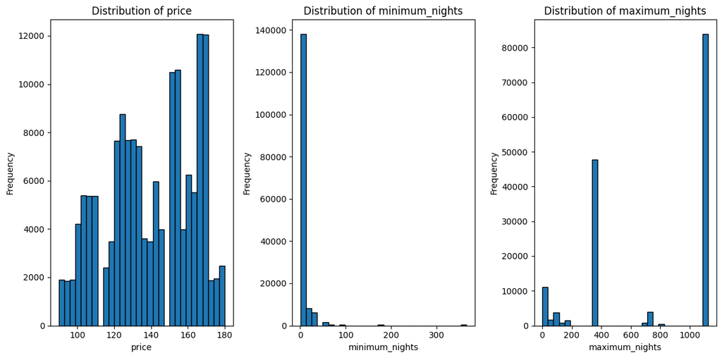

```python
# Check the distribution of numerical columns
fig,axes = plt.subplots(1,3,figsize=(12,6))

# Loop over each column in num_cal to plot on the appropriate subplot axis
for i, col in enumerate(num_cal):
    axes[i].hist(num_cal[col], bins=30, edgecolor='black')
    axes[i].set_title(f'Distribution of {col}')
    axes[i].set_xlabel(col)
    axes[i].set_ylabel('Frequency')

plt.tight_layout()
plt.show()
```

- The average price per month

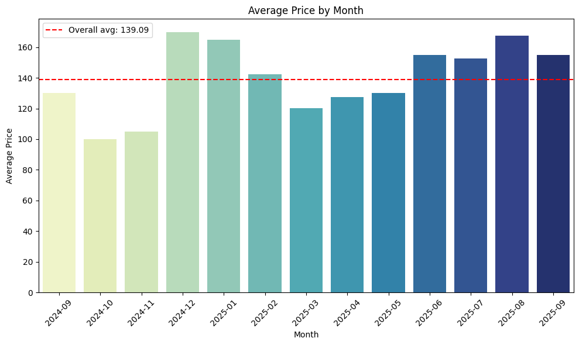

```python
# Average price by month
month_price = calendar.groupby('date_month')['price'].mean()

# Create a bar plot
plt.figure(figsize=(10, 6))
sns.barplot(x=month_price.index, y=month_price.values, palette='YlGnBu')

# Adding labels and title
plt.xlabel('Month')
plt.ylabel('Average Price')
plt.title('Average Price by Month')

# Add a horizontal line for overall average price with correct f-string formatting
plt.axhline(calendar['price'].mean(), color='red', linestyle='--', label=f'Overall avg: {calendar["price"].mean():.2f}')
plt.xticks(rotation=45)  # Add rotation for readability
plt.legend()
plt.tight_layout()
plt.show()
```

- The trend of price by every month

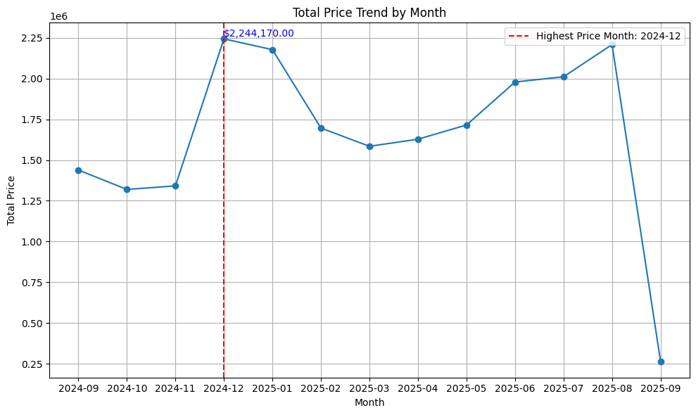

```python
# Price trend by month
month_price_sum = calendar.groupby('date_month')['price'].sum()

# Find the month with the highest price
max_month = month_price_sum.idxmax()  # Month with the highest value
max_value = month_price_sum.max()     # Highest value

# Plot the total price trend by month
plt.figure(figsize=(10, 6))
plt.plot(month_price_sum.index, month_price_sum.values, marker='o', linestyle='-')
plt.title('Total Price Trend by Month')
plt.xlabel('Month')
plt.ylabel('Total Price')
plt.grid(True)

# Add a vertical line at the month with the highest price
plt.axvline(x=max_month, color='r', linestyle='--', label=f'Highest Price Month: {max_month}')

# Add a text annotation for the highest price value, formatted with $ and comma
plt.text(max_month, max_value, f'${max_value:,.2f}', color='blue', verticalalignment='bottom')

# Show legend in the upper right corner
plt.legend(loc='upper right')
plt.tight_layout()
plt.show()
```

#### `Listing` EDA

- Room type percentage

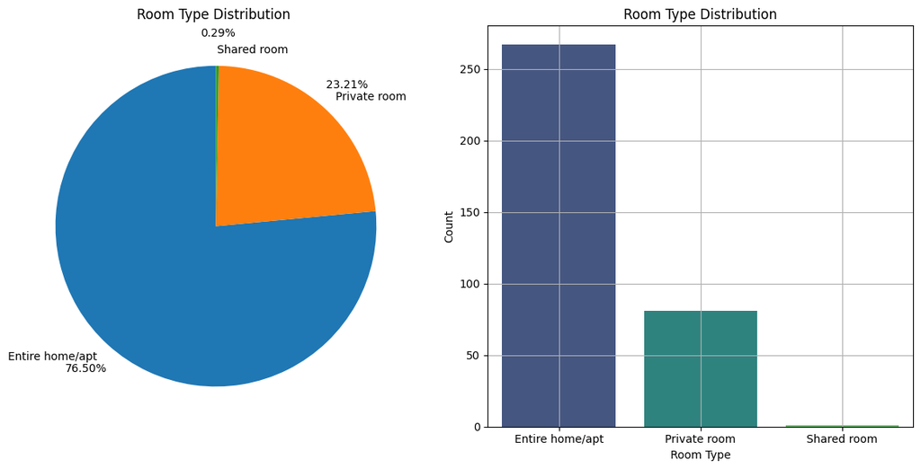

```python
# Check room types distributions and plot the pie and bar charts
room_type_counts = listing['room_type'].value_counts()

# Create subplots for pie chart and bar chart
fig, axes = plt.subplots(1, 2, figsize=(12, 6))

# Pie chart for room type distribution with specific colors
# colors = ['#0000FF', '#008000']
axes[0].pie(room_type_counts.values, autopct='%.2f%%', labels=room_type_counts.index, startangle=90, pctdistance=1.2)
axes[0].set_title('Room Type Distribution ')

# Bar chart for room type counts with same colors
sns.barplot(x=room_type_counts.index, y=room_type_counts.values, ax=axes[1], palette='viridis')
axes[1].set_title('Room Type Distribution')
axes[1].set_xlabel('Room Type')
axes[1].set_ylabel('Count')
axes[1].grid(True)
plt.tight_layout()
plt.show()
```

- Top 10 popular neighbourhoods

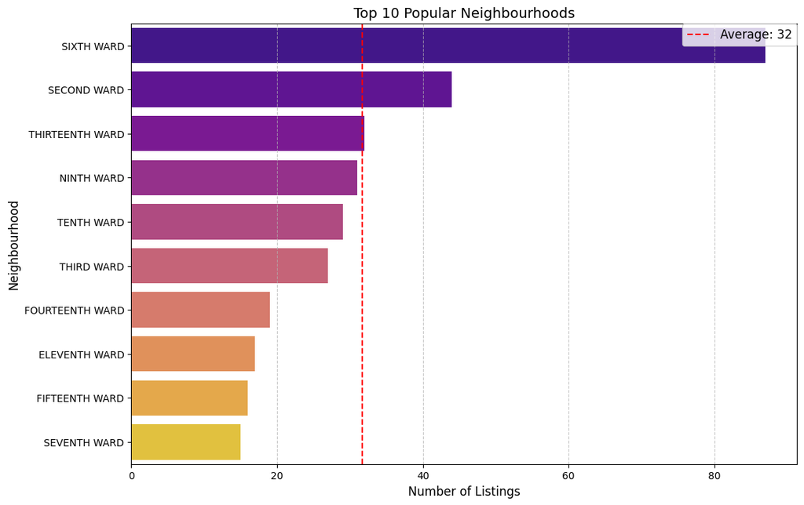

```python
# Count the number of listings in each neighbourhood
neighbourhood_counts = listing['neighbourhood'].value_counts()

# Limit to top 10 neighbourhoods for clarity
top_neighbourhoods = neighbourhood_counts.head(10)
# Average of top 10 number of listing
average_listings = top_neighbourhoods.mean()

# Create a horizontal barplot to display the neighbourhood counts
plt.figure(figsize=(12, 8))
sns.barplot(y=top_neighbourhoods.index, x=top_neighbourhoods.values, orient='h', palette='plasma')

# Add labels and title
plt.xlabel('Number of Listings', fontsize=12)
plt.ylabel('Neighbourhood', fontsize=12)
plt.title('Top 10 Popular Neighbourhoods', fontsize=14)

plt.axvline(x=average_listings, color='red', linestyle='--', label=f'Average: {average_listings:.0f}')
plt.legend(loc='upper right', bbox_to_anchor=(1, 1), borderaxespad=0., fontsize=12)
plt.grid(axis='x', linestyle='--', alpha=0.7)

plt.show()
```

```python
# !pip install folium
```

```python
import folium
from folium.plugins import HeatMap
import pandas as pd

# Prepare data of latitude and longitude columns
top_neighbourhoods = listing[listing['neighbourhood'].isin(neighbourhood_counts.head(10).index)]
neighbourhood_coords = top_neighbourhoods.groupby('neighbourhood')[['latitude', 'longitude']].mean()
neighbourhood_counts = top_neighbourhoods['neighbourhood'].value_counts()

# Combine counts with coordinates
neighbourhood_data = pd.DataFrame({
    'neighbourhood': neighbourhood_counts.index,
    'count': neighbourhood_counts.values
}).merge(neighbourhood_coords, on='neighbourhood')

# Create a base map centered around the average location
m = folium.Map(
    location=[neighbourhood_coords['latitude'].mean(), neighbourhood_coords['longitude'].mean()],
    zoom_start=12
)

# Add HeatMap layer
heat_data = [
    [row['latitude'], row['longitude'], row['count']]
    for _, row in neighbourhood_data.iterrows()
]

HeatMap(heat_data).add_to(m)
m.save(r"E:\Desktop\Semster3\DAB303Marketing\indi_proj\Airbnb_Albany_NY_dataset\top_neighbourhoods_heatmap.html")
m
```

Make this Notebook Trusted to load map: File -> Trust Notebook

[interactive chart not shown]

- Room type of each neighbourhood

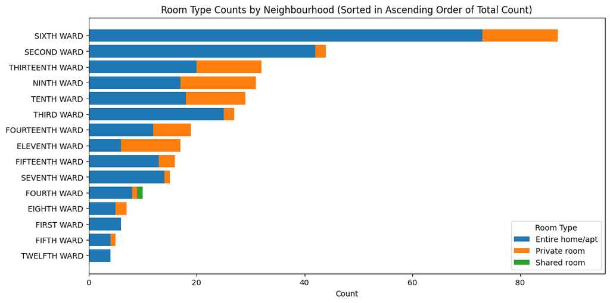

```python
# Aggregate the grouped data, counting occurrences of each room_type in each neighbourhood
neighbour_room_type_counts = listing.groupby(['neighbourhood', 'room_type']).size().unstack(fill_value=0)

# Sort the DataFrame by the total count in ascending order
neighbour_room_type_counts['Total'] = neighbour_room_type_counts.sum(axis=1)
neighbour_room_type_counts = neighbour_room_type_counts.sort_values(by='Total', ascending=True)
neighbour_room_type_counts = neighbour_room_type_counts.drop(columns='Total')  # Drop the 'Total' column after sorting

# Plot the stacked bar chart
plt.figure(figsize=(12, 6))
index = neighbour_room_type_counts.index
columns = neighbour_room_type_counts.columns

# Initialize the 'left' variable to accumulate the bars
left = [0] * len(index)

# Loop through each room_type column and plot it in a stacked manner
for col in columns:
    plt.barh(index, neighbour_room_type_counts[col], left=left, label=col)
    left += neighbour_room_type_counts[col]  # Update 'left' to stack the next bar

# Manually set the x-axis limit if needed
max_value = neighbour_room_type_counts.sum(axis=1).max()
plt.xlim(0, max_value * 1.1)  # Set x-axis limit slightly above the max total to give some padding

# Add legend and labels
plt.legend(title="Room Type")
plt.xlabel("Count")
plt.title("Room Type Counts by Neighbourhood (Sorted in Ascending Order of Total Count)")
plt.show()
```

- Number of listing per host

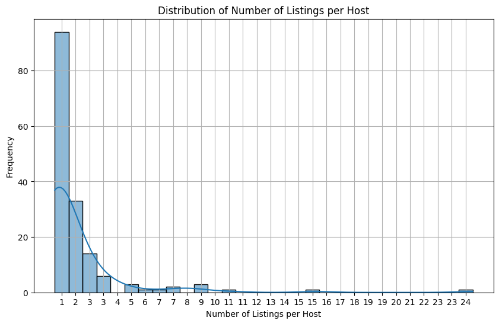

```python
# Calculate the host house listing counts
host_num = listing['host_id'].value_counts()

# Define the number of bins
bins = 30
bin_edges = np.linspace(host_num.min(), host_num.max(), bins + 1)
bin_centers = (bin_edges[:-1] + bin_edges[1:]) / 2

# Plot the histogram
plt.figure(figsize=(10, 6))
sns.histplot(host_num, bins=bin_edges, kde=True)

# Set x-ticks at the center of each bin
plt.xticks(bin_centers, labels=[f"{int(center)}" for center in bin_centers])

# Add labels and title
plt.xlabel('Number of Listings per Host')
plt.ylabel('Frequency')
plt.title('Distribution of Number of Listings per Host')
plt.grid(True)
plt.show()
```

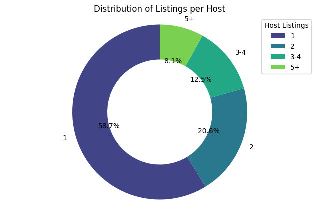

```python
# Bin the data
host_num_bins = pd.cut(host_num, bins=[1, 2, 3, 5, 100], include_lowest=True, right=False,
                       labels=['1', '2', '3-4', '5+']).value_counts()

# Plot the ring chart
plt.figure(figsize=(8, 5))
colors = sns.color_palette('viridis', len(host_num_bins))  # Color palette
plt.pie(host_num_bins, autopct='%1.1f%%', labels=host_num_bins.index, startangle=90, colors=colors,
        wedgeprops={'width': 0.4})  # Set width to create the donut effect
plt.legend(host_num_bins.index, title='Host Listings')
plt.title('Distribution of Listings per Host')
plt.axis('equal')  # Equal aspect ratio ensures the pie chart is circular
plt.show()
```

- Box plot of numerical columns of `Listing`

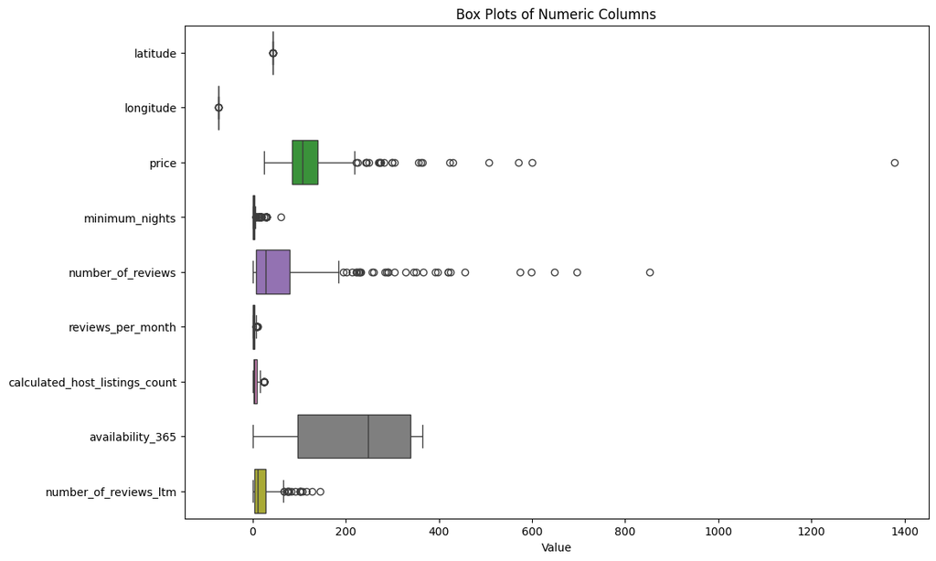

```python
# Select the numerical columns of listing
listing_num = listing.select_dtypes(np.number)

# Create a box plot for each numeric column
plt.figure(figsize=(12, 8))
sns.boxplot(data=listing_num, orient='h')
plt.title("Box Plots of Numeric Columns")
plt.xlabel("Value")
plt.show()
```

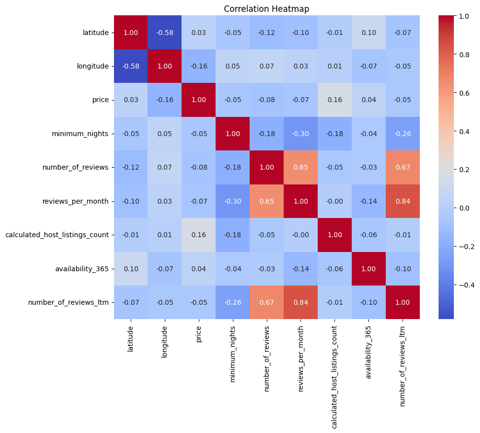

```python
# make numerical columns in listing data
num_listing = listing.select_dtypes(np.number)

# create heatmap to see the numerical columns correlations
correlation_matrix = num_listing.corr()
plt.figure(figsize=(10, 8))
sns.heatmap(correlation_matrix, annot=True, cmap='coolwarm', fmt=".2f")
plt.title('Correlation Heatmap')
plt.show()
```

- Pairplot for selected columns

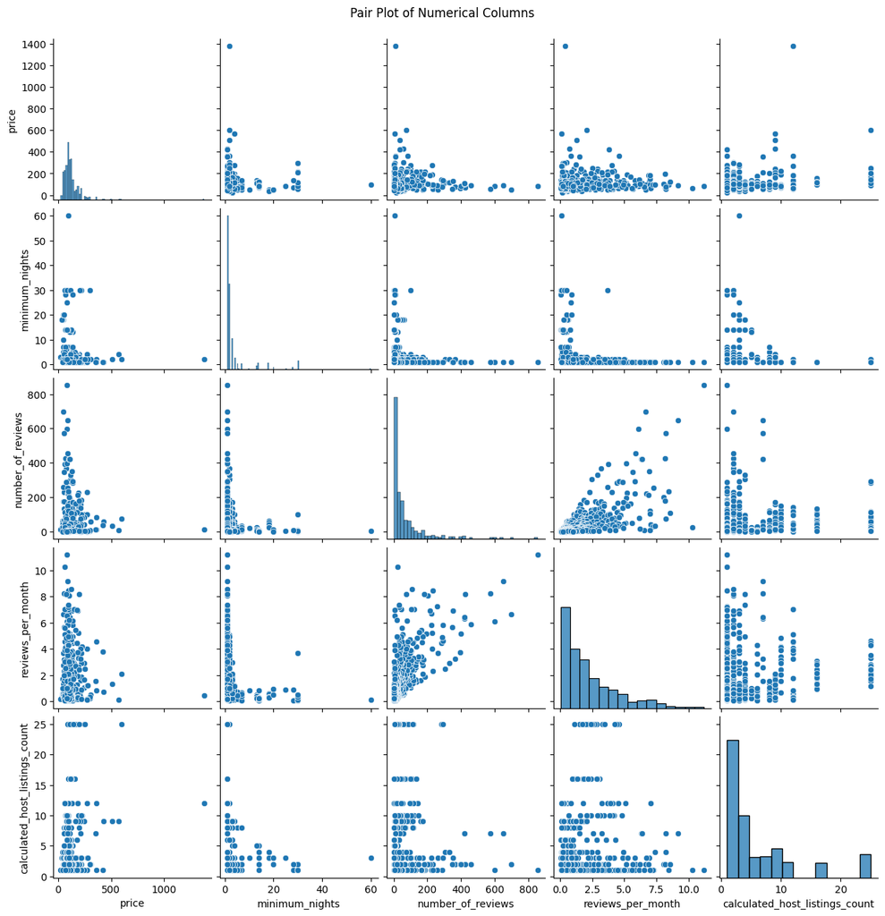

```python
# Create a pair plot for the specified numerical columns
listing_col = ['price', 'minimum_nights', 'number_of_reviews',
               'reviews_per_month', 'calculated_host_listings_count']

sns.pairplot(listing[listing_col])
plt.suptitle("Pair Plot of Numerical Columns", y=1.02)  # Add a title with spacing adjustment
plt.show()
```

#### `Reviews` EDA

- Number of reviews per year

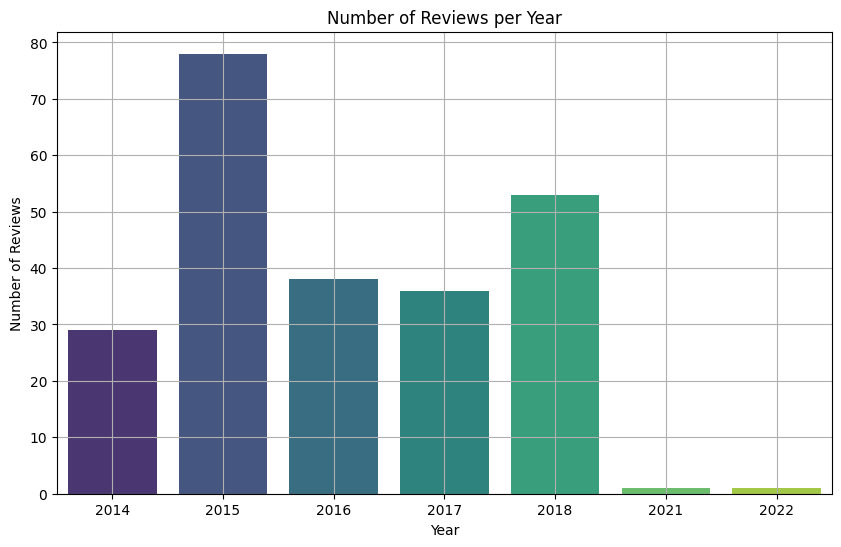

```python
# The year of highest number of reviews
# Group the number of reviews of years
n_reviews_year = reviews.groupby('year').size()

# Create a barplot with different colors
plt.figure(figsize=(10,6))
sns.barplot(x=n_reviews_year.index, y=n_reviews_year.values, palette='viridis')
# Add labels and title
plt.xlabel('Year')
plt.ylabel('Number of Reviews')
plt.grid(True)
plt.title('Number of Reviews per Year')
plt.show()
```

- Number of reviews per month overall

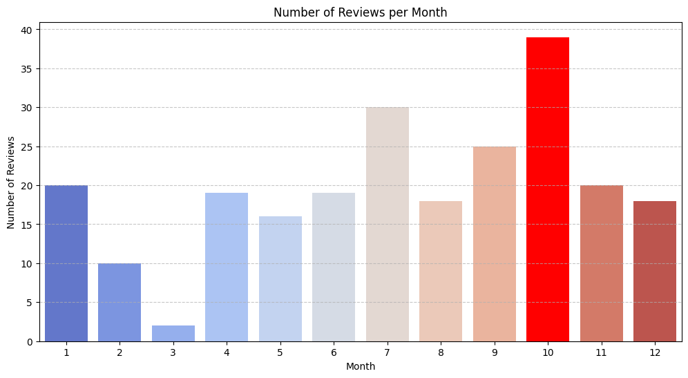

```python
# Group reviews by month, ensuring the month order is correct
n_reviews_month = reviews.groupby('month').size()
n_reviews_month = n_reviews_month.reindex(range(1, 13), fill_value=0)  # Ensure all months are represented

# Create a barplot with a color palette and annotations
plt.figure(figsize=(12, 6))
barplot = sns.barplot(x=n_reviews_month.index, y=n_reviews_month.values, palette='coolwarm')

# Highlight the month with the highest number of reviews
max_reviews = n_reviews_month.max()
max_index = n_reviews_month.idxmax()-1  # Adjust for zero-based index
barplot.patches[max_index].set_facecolor('red')

# Add labels and title
plt.xlabel('Month')
plt.ylabel('Number of Reviews')
plt.title('Number of Reviews per Month')
plt.grid(axis='y', linestyle='--', alpha=0.7)
plt.show()
```

- Monthly Review Count by Year

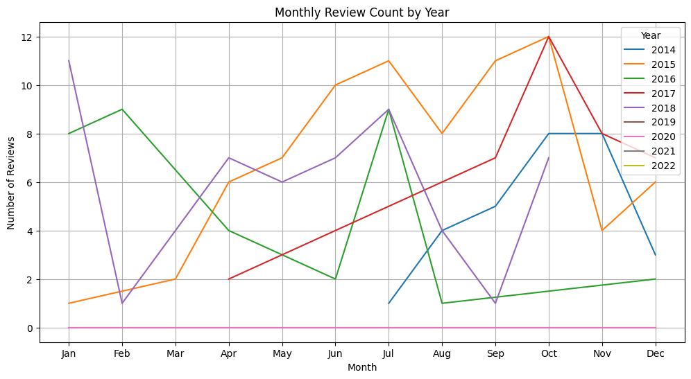

```python
# Ensure all years from the minimum to maximum year are included in the index
all_years = range(reviews['year'].min(), reviews['year'].max() + 1)
year_month_reviews = reviews.groupby(['year', 'month']).size().unstack('month').reindex(all_years, fill_value=0)

# Create the plot
fig, ax = plt.subplots(figsize=(12, 6))
for index in year_month_reviews.index:
    series = year_month_reviews.loc[index]
    sns.lineplot(x=series.index, y=series.values, ax=ax, label=index)  # Use label=index to make sure each year is labeled

# Customize the x-ticks and labels
ax.legend(title="Year",loc ='upper right')
ax.grid()
ax.set_xticks(list(range(1, 13)))
ax.set_xticklabels(['Jan', 'Feb', 'Mar', 'Apr', 'May', 'Jun', 'Jul', 'Aug', 'Sep', 'Oct', 'Nov', 'Dec'])
ax.set_xlabel("Month")
ax.set_ylabel("Number of Reviews")
ax.set_title("Monthly Review Count by Year")
plt.show()
```

#### Advanced analysis

- RFM analysis

```python
# Set the reference date to the latest date in `last_review`
reference_date = listing['last_review'].max()

# Group by 'id' to calculate Recency, Frequency, and Monetary
rfm = listing.groupby('id').agg(
    Recency=('last_review', lambda x: (reference_date - x.max()).days),  # Days since last review
    Frequency=('number_of_reviews', 'sum'),  # Total number of reviews as frequency
    Monetary=('price', 'mean')  # Average price per listing as monetary value
).reset_index()

# Display the resulting RFM matrix
rfm.head()
```

|  | id | Recency | Frequency | Monetary |
| --- | --- | --- | --- | --- |
| 0 | 2992450 | 749 | 9 | 70.0 |
| 1 | 3820211 | 35 | 305 | 116.0 |
| 2 | 5651579 | 8 | 366 | 75.0 |
| 3 | 6623339 | 35 | 328 | 116.0 |
| 4 | 8035768 | 220 | 56 | 305.0 |

```python
from sklearn.preprocessing import StandardScaler
# Initialize the scaler
scaler = StandardScaler()

# Fit and transform the RFM matrix (excluding 'id') and create a new DataFrame with the scaled values
rfm_scaled_values = scaler.fit_transform(rfm[['Recency', 'Frequency', 'Monetary']])

# Create a DataFrame with the scaled values and retain the 'id' column
rfm_scaled = pd.DataFrame(rfm_scaled_values, columns=['Recency', 'Frequency', 'Monetary'])
rfm_scaled['id'] = rfm['id']

# Reorder columns to keep 'id' as the first column
rfm_scaled = rfm_scaled[['id', 'Recency', 'Frequency', 'Monetary']]
rfm_scaled.head()
```

|  | id | Recency | Frequency | Monetary |
| --- | --- | --- | --- | --- |
| 0 | 2992450 | 2.992800 | -0.542426 | -0.570340 |
| 1 | 3820211 | -0.270665 | 2.114511 | -0.106944 |
| 2 | 5651579 | -0.394074 | 2.662055 | -0.519971 |
| 3 | 6623339 | -0.270665 | 2.320962 | -0.106944 |
| 4 | 8035768 | 0.574910 | -0.120548 | 1.797008 |

- Listing house segementation

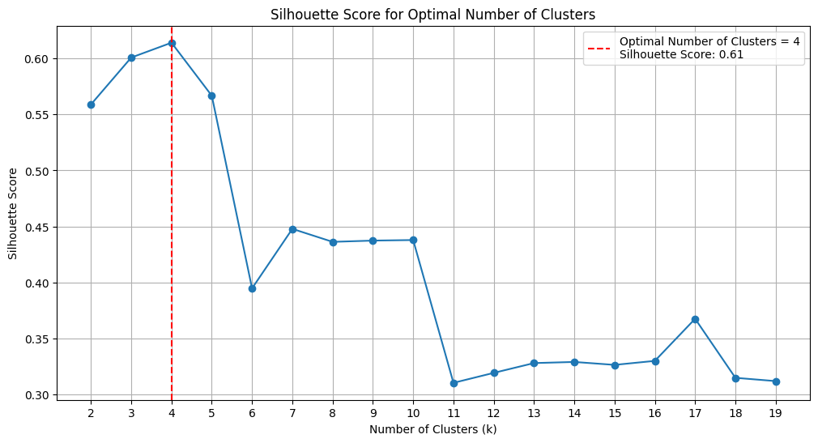

```
Optimal number of clusters based on silhouette score: 4
```

|  | id | Recency | Frequency | Monetary | Cluster |
| --- | --- | --- | --- | --- | --- |
| 0 | 2992450 | 2.992800 | -0.542426 | -0.570340 | 2 |
| 1 | 3820211 | -0.270665 | 2.114511 | -0.106944 | 3 |
| 2 | 5651579 | -0.394074 | 2.662055 | -0.519971 | 3 |
| 3 | 6623339 | -0.270665 | 2.320962 | -0.106944 | 3 |
| 4 | 8035768 | 0.574910 | -0.120548 | 1.797008 | 0 |

```python
from sklearn.metrics import silhouette_score
from sklearn.cluster import KMeans

# Define a range for the number of clusters
silhouette_scores = []  # List to store the silhouette score for each number of clusters
cluster_range = range(2, 20)  # Start from 2 clusters, as silhouette score is not defined for 1 cluster

# Fit KMeans for each cluster count and calculate the silhouette score
for k in cluster_range:
    kmeans = KMeans(n_clusters=k, random_state=88)
    cluster_labels = kmeans.fit_predict(rfm_scaled[['Recency', 'Frequency', 'Monetary']])
    silhouette_avg = silhouette_score(rfm_scaled[['Recency', 'Frequency', 'Monetary']], cluster_labels)
    silhouette_scores.append(silhouette_avg)

# Find the optimal number of clusters based on the highest silhouette score
optimal_k = cluster_range[np.argmax(silhouette_scores)]

# Plot the silhouette scores for each cluster count
plt.figure(figsize=(12, 6))
plt.plot(cluster_range, silhouette_scores, marker='o')
plt.xlabel('Number of Clusters (k)')
plt.ylabel('Silhouette Score')
plt.title('Silhouette Score for Optimal Number of Clusters')
plt.axvline(x=optimal_k, linestyle='--', color='r',
            label=f'Optimal Number of Clusters = {optimal_k}\nSilhouette Score: {np.max(silhouette_scores):.2f}')
plt.legend(loc='best')
plt.xticks(range(2, 20))
plt.grid(True)
plt.show()

# Apply KMeans clustering based on the optimal number of clusters
# Fit KMeans with the optimal number of clusters
kmeans = KMeans(n_clusters=optimal_k, random_state=88)
rfm_scaled['Cluster'] = kmeans.fit_predict(rfm_scaled[['Recency', 'Frequency', 'Monetary']])

# Display the unique clusters found and sample of clustered RFM data
print(f"Optimal number of clusters based on silhouette score: {optimal_k}")
rfm_scaled[['id', 'Recency', 'Frequency', 'Monetary', 'Cluster']].head()
```

```python
reviews.head()
```

|  | listing_id | id | date | reviewer_id | reviewer_name | comments | year | month |
| --- | --- | --- | --- | --- | --- | --- | --- | --- |
| 0 | 2992450 | 15066586 | 2014-07-01 | 16827297 | Kristen | Large apartment; nice kitchen and bathroom. Ke... | 2014 | 7 |
| 1 | 2992450 | 21810844 | 2014-10-24 | 22648856 | Christopher | This may be a little late, but just to say Ken... | 2014 | 10 |
| 2 | 2992450 | 27434334 | 2015-03-04 | 45406 | Altay | The apartment was very clean and convenient to... | 2015 | 3 |
| 3 | 2992450 | 28524578 | 2015-03-25 | 5485362 | John | Kenneth was ready when I got there and arrange... | 2015 | 3 |
| 4 | 2992450 | 35913434 | 2015-06-23 | 15772025 | Jennifer | We were pleased to see how 2nd Street and the ... | 2015 | 6 |

##### Sentimental Analysis

[figure not shown]

```python
from wordcloud import WordCloud

# Concatenate all comments into a single string
all_comments = " ".join(comment for comment in reviews['comments'].dropna())

# Generate the word cloud
wordcloud = WordCloud(
    width=800,
    height=400,
    background_color='white',
    colormap='viridis',
    stopwords=None
).generate(all_comments)

# Visualize the word cloud
plt.figure(figsize=(10, 5))
plt.imshow(wordcloud, interpolation='bilinear')
plt.axis('off')  # Turn off axis
plt.show()
```

```python
from textblob import TextBlob

# Function to classify comments
def classify_sentiment(comment):
    analysis = TextBlob(comment)
    if analysis.sentiment.polarity > 0:
        return 'positive'
    elif analysis.sentiment.polarity < 0:
        return 'negative'
    else:
        return 'neutral'

# Apply the function to the comments
reviews['sentiment'] = reviews['comments'].apply(lambda x: classify_sentiment(x) if pd.notnull(x) else 'neutral')

# Separate positive and negative comments
positive_comments = reviews[reviews['sentiment'] == 'positive']
negative_comments = reviews[reviews['sentiment'] == 'negative']

print("Positive Comments:")
print(positive_comments['comments'])

print("\nNegative Comments:")
print(negative_comments['comments'])
```

```
Positive Comments:
0      Large apartment; nice kitchen and bathroom. Ke...
1      This may be a little late, but just to say Ken...
2      The apartment was very clean and convenient to...
3      Kenneth was ready when I got there and arrange...
4      We were pleased to see how 2nd Street and the ...
                             ...
231    Amazing location, Easy check-in. Overall great...
232    This was my second time staying in the old pre...
233    The place was wonderful! My family and I staye...
234    Terra’s apartment is ideal, excellent location...
235    Awesome apartment close to everything in Alban...
Name: comments, Length: 233, dtype: object

Negative Comments:
8    It was much dirtier in person and half the fur...
Name: comments, dtype: object
```

```python
from nltk.sentiment.vader import SentimentIntensityAnalyzer
import nltk

# Download the VADER lexicon
nltk.download('vader_lexicon')

# Initialize the VADER SentimentIntensityAnalyzer
sid = SentimentIntensityAnalyzer()

# Function to classify sentiment using VADER
def classify_vader(comment):
    scores = sid.polarity_scores(comment)
    if scores['compound'] > 0.05:  # Positive threshold
        return 'positive'
    elif scores['compound'] < -0.05:  # Negative threshold
        return 'negative'
    else:
        return 'neutral'

# Apply the VADER sentiment analysis
reviews['sentiment'] = reviews['comments'].apply(lambda x: classify_vader(x) if pd.notnull(x) else 'neutral')

# Extract positive and negative comments
positive_comments = reviews[reviews['sentiment'] == 'positive']
negative_comments = reviews[reviews['sentiment'] == 'negative']
```

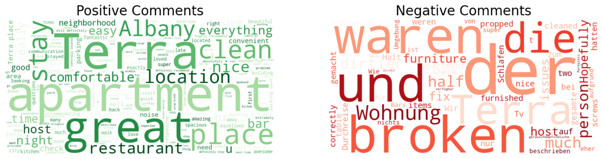

```python
# Generate word cloud for positive comments
positive_text = " ".join(comment for comment in positive_comments['comments'].dropna())
positive_wordcloud = WordCloud(
    width=800,
    height=400,
    background_color='white',
    colormap='Greens'  # Green for positive comments
).generate(positive_text)

# Generate word cloud for negative comments
negative_text = " ".join(comment for comment in negative_comments['comments'].dropna())
negative_wordcloud = WordCloud(
    width=800,
    height=400,
    background_color='white',
    colormap='Reds'  # Red for negative comments
).generate(negative_text)

# Plot the word clouds
plt.figure(figsize=(16, 8))

# Positive comments word cloud
plt.subplot(1, 2, 1)
plt.imshow(positive_wordcloud, interpolation='bilinear')
plt.title('Positive Comments', fontsize=20)
plt.axis('off')

# Negative comments word cloud
plt.subplot(1, 2, 2)
plt.imshow(negative_wordcloud, interpolation='bilinear')
plt.title('Negative Comments', fontsize=20)
plt.axis('off')

plt.show()
```

#### Model Prediction

```python
from sklearn.model_selection import train_test_split
from sklearn.ensemble import RandomForestRegressor
from sklearn.metrics import mean_squared_error, r2_score

# Select relevant features
features = listing[['neighbourhood', 'latitude', 'longitude', 'room_type',
                    'minimum_nights', 'calculated_host_listings_count', 'availability_365']]
target = listing['price']

# Perform any necessary encoding for categorical features
features = pd.get_dummies(features, drop_first=True)

# Split the data into training and testing sets
x_train, x_test, y_train, y_test = train_test_split(features, target, random_state=88, test_size=0.2)

# Initialize and fit the model
model = RandomForestRegressor(random_state=88)
model.fit(x_train, y_train)

# Make predictions
y_pred = model.predict(x_test)

# Evaluate the model
mse = mean_squared_error(y_test, y_pred)
rmse = np.sqrt(mse)
r2 = r2_score(y_test, y_pred)

print(f"RMSE: {rmse:.4f}")
print(f"R^2 Score: {r2:.4f}")
```

```
RMSE: 53.5558
R^2 Score: 0.1712
```

```python
from xgboost import XGBRegressor
# Set the XGboost model
model = XGBRegressor(random_state=88)
model.fit(x_train, y_train)

# Predict the dataset
y_pred = model.predict(x_test)

# Evaluate the model
mse = mean_squared_error(y_test, y_pred)
rmse = np.sqrt(mse)
r2 = r2_score(y_test, y_pred)

print(f"RMSE: {rmse:.4f}")
print(f"R^2 Score: {r2:.4f}")
```

```
RMSE: 81.4650
R^2 Score: -0.9178
```

```python
from sklearn.tree import DecisionTreeRegressor
# Build the DecisionTree model
model = DecisionTreeRegressor(random_state=88)
model.fit(x_train, y_train)

# Preidct
y_pred = model.predict(x_test)

# Evaluate the model
mse = mean_squared_error(y_test, y_pred)
rmse = np.sqrt(mse)
r2 = r2_score(y_test, y_pred)

print(f"RMSE: {rmse:.4f}")
print(f"R^2 Score: {r2:.4f}")
```

```
RMSE: 61.6509
R^2 Score: -0.0983
```

```python
from sklearn.linear_model import Lasso
# Build Lasso model and initialize the model
model = Lasso(alpha=0.1, random_state=88)
model.fit(x_train, y_train)

# Predict
y_pred = model.predict(x_test)

# Evaluate the model
mse = mean_squared_error(y_test, y_pred)
rmse = np.sqrt(mse)
r2 = r2_score(y_test, y_pred)

print(f"RMSE: {rmse:.4f}")
print(f"R^2 Score: {r2:.4f}")
```

```
RMSE: 54.5534
R^2 Score: 0.1400
```

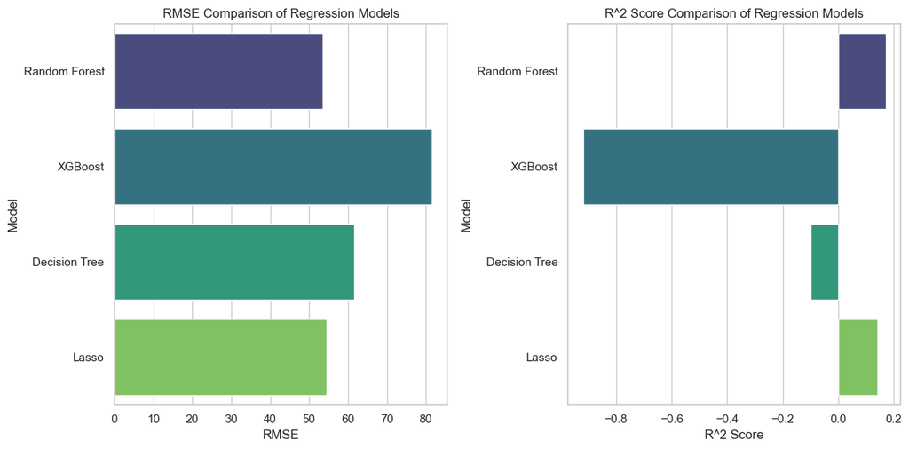

```python
import pandas as pd
import numpy as np
import matplotlib.pyplot as plt
import seaborn as sns
from sklearn.model_selection import train_test_split
from sklearn.ensemble import RandomForestRegressor
from sklearn.tree import DecisionTreeRegressor
from sklearn.linear_model import Lasso
from xgboost import XGBRegressor
from sklearn.metrics import mean_squared_error, r2_score


# Create the list of the model test
models = {
    "Random Forest": RandomForestRegressor(random_state=88),
    "XGBoost": XGBRegressor(random_state=88),
    "Decision Tree": DecisionTreeRegressor(random_state=88),
    "Lasso": Lasso(alpha=0.1, random_state=88)
}

results = []

# Get the model performance for each
for model_name, model in models.items():
    model.fit(x_train, y_train)
    y_pred = model.predict(x_test)

    mse = mean_squared_error(y_test, y_pred)
    rmse = np.sqrt(mse)
    r2 = r2_score(y_test, y_pred)

    results.append({
        'Model': model_name,
        'RMSE': rmse,
        'R^2 Score': r2
    })

results_df = pd.DataFrame(results)

sns.set(style="whitegrid")

# PLot the RMSE
plt.figure(figsize=(12, 6))
plt.subplot(1, 2, 1)
sns.barplot(x='RMSE', y='Model', data=results_df, palette='viridis')
plt.title('RMSE Comparison of Regression Models')

# Plot R²
plt.subplot(1, 2, 2)
sns.barplot(x='R^2 Score', y='Model', data=results_df, palette='viridis')
plt.title('R^2 Score Comparison of Regression Models')

plt.tight_layout()
plt.show()
```

##### Top10 feature importance for prediction

[figure not shown]

```python
# Get feature importances
importances = model.feature_importances_
feature_names = features.columns

# Create a DataFrame for feature importances
feature_importance_df = pd.DataFrame({'feature': feature_names, 'importance': importances})
feature_importance_df = feature_importance_df.sort_values(by='importance', ascending=False).head(10)

# Plot feature importances
plt.figure(figsize=(10, 6))
plt.barh(feature_importance_df['feature'], feature_importance_df['importance'], color='skyblue')
plt.gca().invert_yaxis()  # Highest importance at the top
plt.xlabel('Importance')
plt.title('Feature Importance for Price Prediction')
plt.show()
```